# Case 1_Data Analysis Skill Test - 4intelligence

Paulo Eduardo Braga

01/12/2020

# **Objetivo**

Analisar a Produtividade Total dos Fatores (PTF) para os Estados Unidos da América, Canadá e México, entre 1950 a 2011. (Nessa análise considerou-se 2005 como ano-base).

## Importando arquivo PTF

```r
data = read.csv('TFP.csv', header = T)
```

## Item 1 - Análise Exploratória

```r
skim(data)
```

Data summary

| Name | data |
| --- | --- |
| Number of rows | 186 |
| Number of columns | 3 |
| _______________________ |  |
| Column type frequency: |  |
| character | 1 |
| numeric | 2 |
| ________________________ |  |
| Group variables | None |

**Variable type: character**

| skim_variable | n_missing | complete_rate | min | max | empty | n_unique | whitespace |
| --- | --- | --- | --- | --- | --- | --- | --- |
| isocode | 0 | 1 | 3 | 3 | 0 | 3 | 0 |

**Variable type: numeric**

| skim_variable | n_missing | complete_rate | mean | sd | p0 | p25 | p50 | p75 | p100 | hist |
| --- | --- | --- | --- | --- | --- | --- | --- | --- | --- | --- |
| year | 0 | 1 | 1980.50 | 17.94 | 1950.00 | 1965.00 | 1980.5 | 1996.00 | 2011.00 | ▇▇▇▇▇ |
| rtfpna | 0 | 1 | 0.98 | 0.18 | 0.62 | 0.86 | 1.0 | 1.05 | 1.38 | ▃▂▇▂▂ |

No gráfico, abaixo, é possível conferir o histograma combinado com a densidade da PTF para os 3 países.

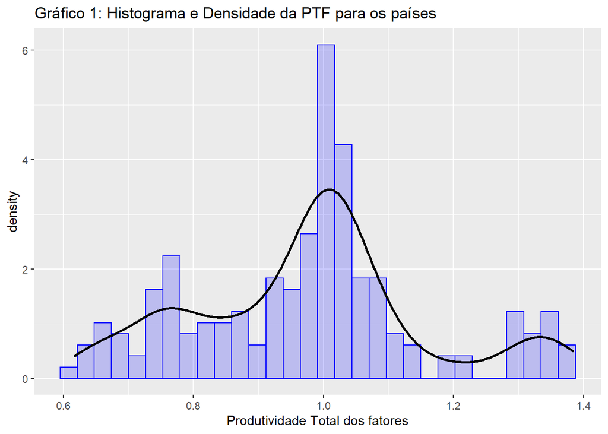

```r
histogram <- ggplot(data= data, aes(x=rtfpna)) +
              geom_histogram(aes(y =..density..),
                             col="blue",
                             fill="blue",
                             alpha=.2) +
              geom_density(col = 'black', size = 1) +
              labs(x='Produtividade Total dos fatores')+labs(title = "Gráfico 1: Histograma e Densidade da PTF para os países")

histogram
```

Nas tabelas e gráficos, abaixo, será possível analisar o comportamento da PTF em cada país.

```r
eua <- subset(data, isocode == 'USA')
can <- subset(data, isocode == 'CAN')
mex <- subset(data, isocode == 'MEX')

summary(eua$rtfpna)
```

```
##    Min. 1st Qu.  Median    Mean 3rd Qu.    Max.
##  0.6171  0.7399  0.7660  0.8038  0.8805  1.0204
```

```r
summary(can$rtfpna)
```

```
##    Min. 1st Qu.  Median    Mean 3rd Qu.    Max.
##  0.8433  0.9733  1.0042  0.9929  1.0295  1.0661
```

```r
summary(mex$rtfpna)
```

```
##    Min. 1st Qu.  Median    Mean 3rd Qu.    Max.
##  0.7982  1.0122  1.0939  1.1301  1.2996  1.3837
```

```r
sd(eua$rtfpna)
```

```
## [1] 0.1161212
```

```r
sd(can$rtfpna)
```

```
## [1] 0.05012575
```

```r
sd(mex$rtfpna)
```

```
## [1] 0.158209
```

Dos 3 países analisado, o Canadá foi o que teve menor variabilidade e amplitude da PTF. Tendo como PTF média, entre o período analisado, de 0,9929 e desvio-padrão de 0,0501. Já o México foi o país que a PTF teve o maior desvio-padrão (0,1582) e com maior amplitude, além de que foi o país que teve a maior PTF média, sendo ela de 1,1301. Há indícios que no México a PTF teve grandes oscilações no período analisado. A PTF média dos EUA foi a menor entre os 3 países, de 0,8038 e com amplitude moderada, acreditando que a evolução da PTF nos EUA foi crescente.

Através do próximo gráfico será possível analisar a variabilidade da PTF para cada país, ao longo do período analisado.

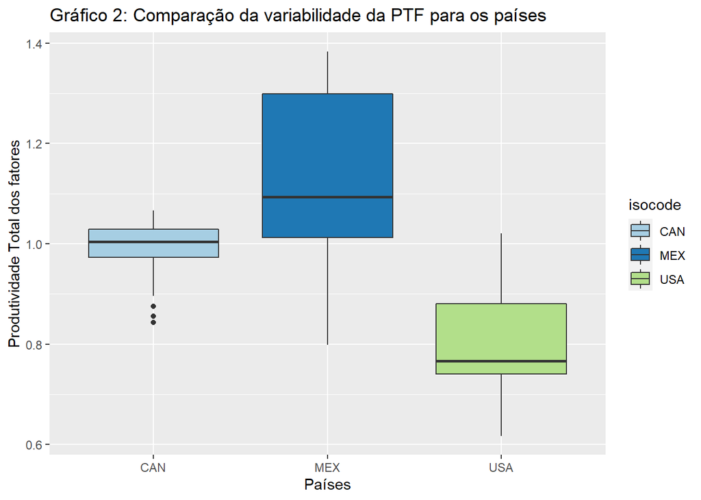

```r
graf_2 <- ggplot(data= data, aes(y=rtfpna, x= isocode)) +
      geom_boxplot(aes(fill = isocode)) +
      labs(y='Produtividade Total dos fatores', x= 'Países')+labs(title = "Gráfico 2: Comparação da variabilidade da PTF para os países") +
      scale_fill_brewer(palette = "Paired")

graf_2
```

Nos Gráficos, abaixo, será possível analisar a evolução da PTF em cada país.

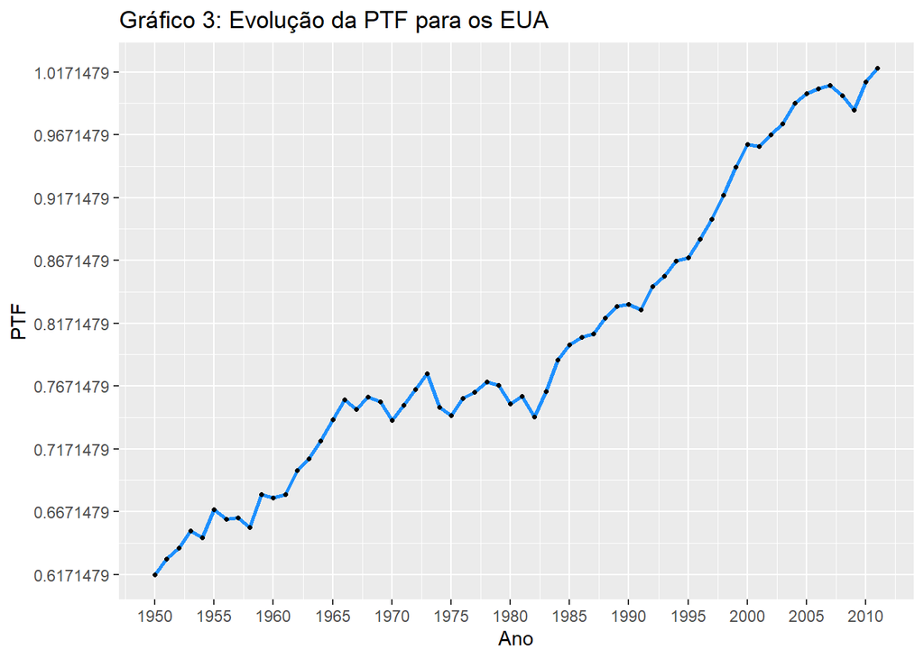

```r
graf_3 <- ggplot(data = eua, aes(x = as.numeric(year), y = as.numeric(rtfpna))) +
      geom_line(color = "#1e90ff", size = 1)  +
      xlab("Ano") + ylab("PTF") + labs(title = "Gráfico 3: Evolução da PTF para os EUA") +
      geom_point(colour = "#000000", size = 0.9) +
      scale_x_continuous(breaks = seq(min(eua$year),max(eua$year), 5)) +
      scale_y_continuous(breaks = seq(min(eua$rtfpna),max(eua$rtfpna), .05))

graf_3
```

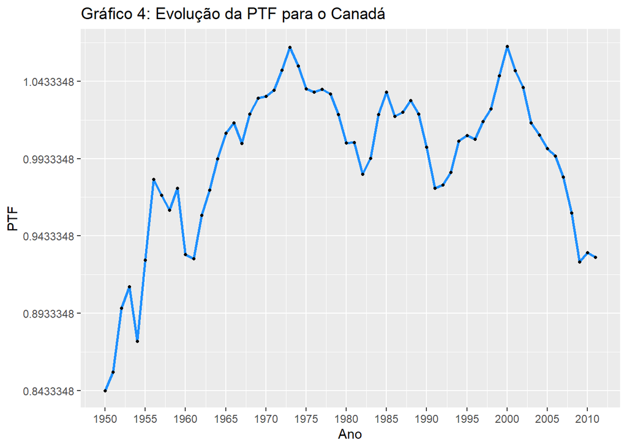

```r
graf_4 <- ggplot(data = can, aes(x = as.numeric(year), y = as.numeric(rtfpna))) +
      geom_line(color = "#1e90ff", size = 1)  +
      xlab("Ano") + ylab("PTF") + labs(title = "Gráfico 4: Evolução da PTF para o Canadá") +
      geom_point(colour = "#000000", size = 0.9)+
      scale_x_continuous(breaks = seq(min(can$year),max(can$year), 5)) +
      scale_y_continuous(breaks = seq(min(can$rtfpna),max(can$rtfpna), .05))

graf_4
```

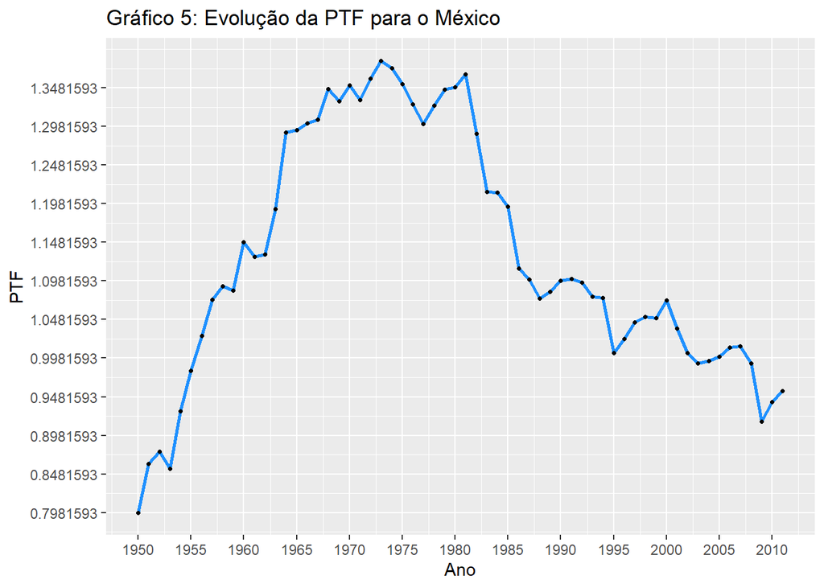

```r
graf_5 <- ggplot(data = mex, aes(x = as.numeric(year), y = as.numeric(rtfpna))) +
      geom_line(color = "#1e90ff", size = 1)  +
      xlab("Ano") + ylab("PTF") + labs(title = "Gráfico 5: Evolução da PTF para o México") +
      geom_point(colour = "#000000", size = 0.9)+
      scale_x_continuous(breaks = seq(min(mex$year),max(mex$year), 5)) +
      scale_y_continuous(breaks = seq(min(mex$rtfpna),max(mex$rtfpna), .05))

graf_5
```

Através do `Gráfico 2` corrobora com o que tinha sido apontado anteriormente, de que a variabilidade da PTF do México foi a maior, e a do Canadá foi a menor. O Canadá foi o único país que apresentou alguns valores “extremos”, que distanciaram da sua média. Esses valores extremos podem ser explicados por anos que a PTF caiu de forma abrupta, porém teve uma recuperada nos anos seguintes (choques).

De uma forma geral, os EUA foi o único país que apresentou um tendência de crescimento durante todo o período analisado. Tanto o México quanto o Canadá tiveram diferentes tendências da PTF em períodos específicos. Concluindo que a PTF nesses dois países, principalmente o México, é suscetível a períodos de crises/recessão.

## Item 2 - Previsão para a PTF

Através do modelo ARIMA relizou-se a previsão da PTF para cada país.

#### 2.1 - Estados Unidos

Prevendo a PTF para os próximos 10 anos nos EUA.

```r
arima_result = auto.arima(data$rtfpna[data$isocode == 'USA'])
```

A especificação sugerida do modelo e principais resultados podem ser encontradas abaixo.

```r
summary(arima_result)
```

```
## Series: data$rtfpna[data$isocode == "USA"]
## ARIMA(0,1,0) with drift
##
## Coefficients:
##        drift
##       0.0066
## s.e.  0.0014
##
## sigma^2 estimated as 0.0001291:  log likelihood=187.09
## AIC=-370.17   AICc=-369.97   BIC=-365.95
##
## Training set error measures:
##                        ME       RMSE         MAE         MPE     MAPE     MASE
## Training set 9.847371e-06 0.01117543 0.009022366 -0.02282104 1.154826 0.799736
##                    ACF1
## Training set 0.03225483
```

```r
previsaoARIMA = forecast(arima_result, h = 10)

previsaoARIMA$method
```

```
## [1] "ARIMA(0,1,0) with drift"
```

A especificação indicada para esse modelo de previsão foi um ARIMA (0,1,0) com constante.

Os valores previstos da PTF para os próximos 10 anos nos EUA estão listados abaixo, junto com o Intervalo de confiança dessa previsão, com 80% e 95% de confiança.

```r
previsao_eua <- as.data.frame(previsaoARIMA)

previsao_eua
```

```
##    Point Forecast    Lo 80    Hi 80    Lo 95    Hi 95
## 63       1.027002 1.012444 1.041561 1.004737 1.049268
## 64       1.033613 1.013024 1.054202 1.002125 1.065101
## 65       1.040223 1.015007 1.065440 1.001659 1.078788
## 66       1.046834 1.017717 1.075951 1.002303 1.091365
## 67       1.053445 1.020891 1.085999 1.003657 1.103232
## 68       1.060055 1.024394 1.095716 1.005516 1.114594
## 69       1.066666 1.028147 1.105184 1.007757 1.125575
## 70       1.073276 1.032098 1.114454 1.010300 1.136253
## 71       1.079887 1.036211 1.123563 1.013090 1.146683
## 72       1.086497 1.040459 1.132536 1.016088 1.156907
```

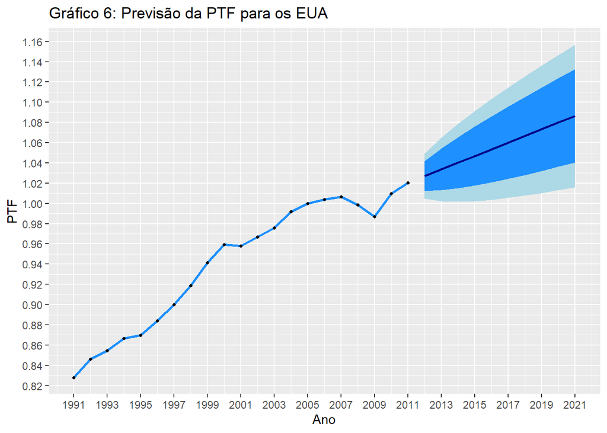

```r
eua1 <- subset(data, isocode == 'USA' & year > 1990)

graf_6 <- ggplot(data = eua1, aes(x = as.numeric(year), y = as.numeric(rtfpna))) +
      geom_line(color = "#1e90ff", size = 1)  +
      xlab("Ano") + ylab("PTF") + labs(title = "Gráfico 6: Previsão da PTF para os EUA") +
      geom_point(colour = "#000000", size = 0.9) +
      geom_ribbon(aes(x=c(2012,2013,2014,2015,2016,2017,2018,2019,2020,2021),
                    y=`Point Forecast`,
                    ymax= `Hi 95`, ymin= `Lo 95`),
                 data=previsao_eua, fill="#add8e6") +
      geom_ribbon(aes(x=c(2012,2013,2014,2015,2016,2017,2018,2019,2020,2021),
                      y=`Point Forecast`,
                      ymax= `Hi 80`, ymin= `Lo 80`),
                  data=previsao_eua, fill="#1e90ff") +
      geom_line(aes(x=c(2012,2013,2014,2015,2016,2017,2018,2019,2020,2021),
                    y=`Point Forecast`), data = previsao_eua, color = 'dark blue', size = .8) +
      scale_x_continuous(breaks = seq(min(eua1$year),2030, 2)) +
      scale_y_continuous(breaks = seq(0, 2, .02))

graf_6
```

#### 2.2 - Canadá

Prevendo a PTF para os próximos 10 anos no Canadá.

```r
arima_result = auto.arima(data$rtfpna[data$isocode == 'CAN'])
```

A especificação sugerida do modelo e principais resultados podem ser encontradas abaixo.

```r
summary(arima_result)
```

```
## Series: data$rtfpna[data$isocode == "CAN"]
## ARIMA(0,2,3)
##
## Coefficients:
##           ma1      ma2     ma3
##       -0.6432  -0.4813  0.2222
## s.e.   0.1267   0.1267  0.1163
##
## sigma^2 estimated as 0.0003356:  log likelihood=155.45
## AIC=-302.91   AICc=-302.18   BIC=-294.53
##
## Training set error measures:
##                        ME       RMSE        MAE        MPE    MAPE      MASE
## Training set -0.003392639 0.01756456 0.01330863 -0.3506198 1.36017 0.8848314
##                     ACF1
## Training set -0.03721486
```

```r
previsaoARIMA = forecast(arima_result, h = 10)

previsaoARIMA$method
```

```
## [1] "ARIMA(0,2,3)"
```

A especificação indicada para esse modelo de previsão foi um ARIMA (0,2,3).

Os valores previstos da PTF para os próximos 10 anos no Canadá estão listados abaixo, junto com o Intervalo de confiança dessa previsão, com 80% e 95% de confiança.

```r
previsao_can <- as.data.frame(previsaoARIMA)

previsao_can
```

```
##    Point Forecast     Lo 80     Hi 80     Lo 95     Hi 95
## 63      0.9171747 0.8936983 0.9406512 0.8812706 0.9530788
## 64      0.9123099 0.8727405 0.9518792 0.8517937 0.9728260
## 65      0.9057691 0.8567515 0.9547866 0.8308031 0.9807350
## 66      0.8992282 0.8411095 0.9573470 0.8103433 0.9881132
## 67      0.8926874 0.8255945 0.9597804 0.7900776 0.9952973
## 68      0.8861466 0.8100921 0.9622012 0.7698312 1.0024621
## 69      0.8796058 0.7945364 0.9646753 0.7495033 1.0097084
## 70      0.8730650 0.7788867 0.9672434 0.7290317 1.0170984
## 71      0.8665242 0.7631170 0.9699315 0.7083765 1.0246720
## 72      0.8599834 0.7472099 0.9727569 0.6875112 1.0324556
```

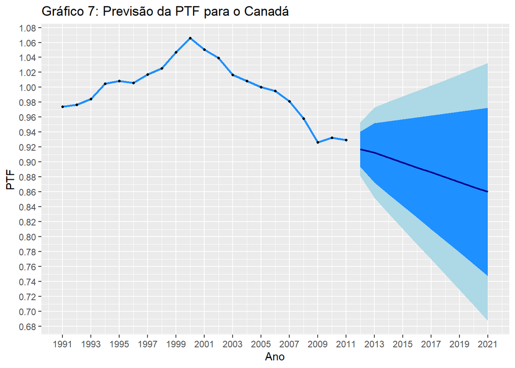

```r
can1 <- subset(data, isocode == 'CAN' & year > 1990)

graf_7 <- ggplot(data = can1, aes(x = as.numeric(year), y = as.numeric(rtfpna))) +
      geom_line(color = "#1e90ff", size = 1)  +
      xlab("Ano") + ylab("PTF") + labs(title = "Gráfico 7: Previsão da PTF para o Canadá") +
      geom_point(colour = "#000000", size = 0.9) +
      geom_ribbon(aes(x=c(2012,2013,2014,2015,2016,2017,2018,2019,2020,2021),
                    y=`Point Forecast`,
                    ymax= `Hi 95`, ymin= `Lo 95`),
                 data=previsao_can, fill="#add8e6") +
      geom_ribbon(aes(x=c(2012,2013,2014,2015,2016,2017,2018,2019,2020,2021),
                      y=`Point Forecast`,
                      ymax= `Hi 80`, ymin= `Lo 80`),
                  data=previsao_can, fill="#1e90ff") +
      geom_line(aes(x=c(2012,2013,2014,2015,2016,2017,2018,2019,2020,2021),
                    y=`Point Forecast`), data = previsao_can, color = 'dark blue', size = .8) +
      scale_x_continuous(breaks = seq(min(can1$year),2030, 2)) +
      scale_y_continuous(breaks = seq(0, 2, .02))

graf_7
```

#### 2.3 - México

Prevendo a PTF para os próximos 10 anos no México.

```r
arima_result = auto.arima(data$rtfpna[data$isocode == 'MEX'])
```

A especificação sugerida do modelo e principais resusltados podem ser encontradas abaixo.

```r
summary(arima_result)
```

```
## Series: data$rtfpna[data$isocode == "MEX"]
## ARIMA(0,2,1)
##
## Coefficients:
##           ma1
##       -0.8502
## s.e.   0.0617
##
## sigma^2 estimated as 0.001167:  log likelihood=117.33
## AIC=-230.65   AICc=-230.44   BIC=-226.46
##
## Training set error measures:
##                        ME       RMSE        MAE        MPE     MAPE     MASE
## Training set -0.004967013 0.03332467 0.02664148 -0.4162653 2.396274 1.004223
##                    ACF1
## Training set 0.04940407
```

```r
previsaoARIMA = forecast(arima_result, h = 10)

previsaoARIMA$method
```

```
## [1] "ARIMA(0,2,1)"
```

A especificação indicada para esse modelo de previsão foi um ARIMA (0,2,1).

Os valores previstos da PTF para os próximos 10 anos no México estão listados abaixo, junto com o Intervalo de confiança dessa previsão, com 80% e 95% de confiança.

```r
previsao_mex <- as.data.frame(previsaoARIMA)

previsao_mex
```

```
##    Point Forecast     Lo 80     Hi 80     Lo 95    Hi 95
## 63      0.9494087 0.9056291 0.9931883 0.8824535 1.016364
## 64      0.9430517 0.8763397 1.0097637 0.8410245 1.045079
## 65      0.9366947 0.8490163 1.0243731 0.8026021 1.070787
## 66      0.9303377 0.8221078 1.0385676 0.7648143 1.095861
## 67      0.9239807 0.7950811 1.0528803 0.7268458 1.121116
## 68      0.9176237 0.7676980 1.0675494 0.6883322 1.146915
## 69      0.9112667 0.7398389 1.0826946 0.6490905 1.173443
## 70      0.9049097 0.7114401 1.0983794 0.6090234 1.200796
## 71      0.8985527 0.6824678 1.1146377 0.5680793 1.229026
## 72      0.8921958 0.6529048 1.1314867 0.5262319 1.258160
```

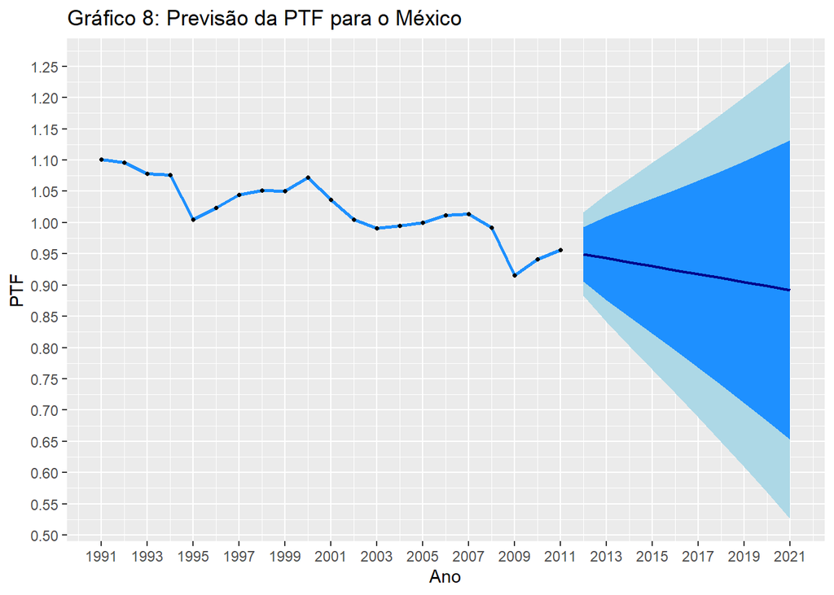

```r
mex1 <- subset(data, isocode == 'MEX' & year > 1990)

graf_8 <- ggplot(data = mex1, aes(x = as.numeric(year), y = as.numeric(rtfpna))) +
      geom_line(color = "#1e90ff", size = 1)  +
      xlab("Ano") + ylab("PTF") + labs(title = "Gráfico 8: Previsão da PTF para o México") +
      geom_point(colour = "#000000", size = 0.9) +
      geom_ribbon(aes(x=c(2012,2013,2014,2015,2016,2017,2018,2019,2020,2021),
                    y=`Point Forecast`,
                    ymax= `Hi 95`, ymin= `Lo 95`),
                 data=previsao_mex, fill="#add8e6") +
      geom_ribbon(aes(x=c(2012,2013,2014,2015,2016,2017,2018,2019,2020,2021),
                      y=`Point Forecast`,
                      ymax= `Hi 80`, ymin= `Lo 80`),
                  data=previsao_mex, fill="#1e90ff") +
      geom_line(aes(x=c(2012,2013,2014,2015,2016,2017,2018,2019,2020,2021),
                    y=`Point Forecast`), data = previsao_mex, color = 'dark blue', size = .8) +
      scale_x_continuous(breaks = seq(min(mex1$year),2030, 2)) +
      scale_y_continuous(breaks = seq(0, 2, .05))

graf_8
```

A previsão da PTF para os EUA foi a única que manteve a tendência de crescimento. Esse resultado foi obtido pois o histórico da PTF dos EUA possui uma tendência positiva entre 1950 a 2011. A previsão da PTF para o Canadá e México apresentou tendência decrescente, porém como a variabilidade da PTF no México foi maior, entre 1950 e 2011, o intervalo de confiança da previsão é maior, quando comparado com o Intervalo de confiança da previsão para o Canadá.

## Item 3 - Informações Adicionais

Segundo Oliveira et al. (2014) a PWT 8.0, é possível analisar a trajetória de variáveis relevantes na avaliação do nível de crescimento e desenvolvimento econômico dos países. Se o objetivo é construir um novo índice que reflita o crescimento da produtividade,poderia utilizar as variáveis:

- cgdpe: PIB real pela ótica da despesa, em PPP (em milhões de dólares, 2005);
- cgdpo: PIB pela ótica da produção, em PPP (em milhões de dólares, 2005);
- rgdpna: PIB real, a preços constantes de 2005 (em milhões de dólares, 2005);

Utilizando, também, outras variáveis que refletissem o nível do produto, estoque de capital físico, capital humano, remuneração dos fatores (terra, mão de obra, juros, alguéis, etc.), análises semelhantes a da PTF poderiam ser feitas.

Nesse caso, poderiam ser utilizadas as variáveis:

- hc : Índice de capital humano por pessoa, baseado em anos de escolaridade (Barro e Lee, 2013) e retornos à educação (Psacharopoulos, 1994);
- avh: Média anual de horas trabalhadas por pessoa;
- ck: Estoque de capital nas PPPs atuais (em milhões de USD em 2005);
- pl_i: Nível de preços de formação de capital (nível de preços do GDPo dos EUA em 2005 = 1);
- pl_k: Nível de preços do estoque de capital (nível de preços dos EUA em 2005 = 1.

## Referências

Oliveira,M.F.de; Matni,G.M.; Caetano,S.M. **CRESCIMENTO ECONÔMICO, GAP DO PRODUTO E PRODUTIVIDADE DA ECONOMIA BRASILEIRA NO PÓS-GUERRA**. Disponível em https://www.bnb.gov.br/documents/160445/226386/ss4_mesa1_artigos2014_crescimento_economico_gap_produto_produtividade.pdf/14f68ffc-e5a6-4373-913a-471b9b6a1346.. Consultado em 30/11/2020.